# Capstone Machine Learning

Alexander Budiman

7/21/2023

### Import Library

```r
library(dplyr)
library(GGally)
library(MLmetrics)
library(recipes)
library(yardstick)
library(randomForest)
library(lime)
library(caret)
```

### Read Data

```r
train <- read.csv("data-train.csv")
test <- read.csv("data-test.csv")
submit <- read.csv("submission-example.csv")
glimpse(train)
```

```
## Rows: 825
## Columns: 10
## $ id          <chr> "S1", "S2", "S3", "S4", "S5", "S6", "S7", "S8", "S9", "S10~
## $ cement      <dbl> 540.0, 540.0, 332.5, 332.5, 198.6, 380.0, 380.0, 475.0, 19~
## $ slag        <dbl> 0.0, 0.0, 142.5, 142.5, 132.4, 95.0, 95.0, 0.0, 132.4, 132~
## $ flyash      <dbl> 0, 0, 0, 0, 0, 0, 0, 0, 0, 0, 0, 0, 0, 0, 0, 0, 0, 0, 0, 0~
## $ water       <dbl> 162, 162, 228, 228, 192, 228, 228, 228, 192, 192, 228, 228~
## $ super_plast <dbl> 2.5, 2.5, 0.0, 0.0, 0.0, 0.0, 0.0, 0.0, 0.0, 0.0, 0.0, 0.0~
## $ coarse_agg  <dbl> 1040.0, 1055.0, 932.0, 932.0, 978.4, 932.0, 932.0, 932.0, ~
## $ fine_agg    <dbl> 676.0, 676.0, 594.0, 594.0, 825.5, 594.0, 594.0, 594.0, 82~
## $ age         <int> 28, 28, 270, 365, 360, 365, 28, 28, 90, 28, 28, 90, 90, 36~
## $ strength    <dbl> 79.99, 61.89, 40.27, 41.05, 44.30, 43.70, 36.45, 39.29, 38~
```

### Data Preprocessing & Exploratory Data Analysis

1. Memeriksa apakah ada kolom yang kosong datanya.

```r
train %>%
   is.na() %>%
  colSums(is.na(train))
```

```
##          id      cement        slag      flyash       water super_plast
##           0           0           0           0           0           0
##  coarse_agg    fine_agg         age    strength
##           0           0           0           0
```

2. Menghilangkan kolom id

```r
train <- train[,-1]
head(train)
```

```
##   cement  slag flyash water super_plast coarse_agg fine_agg age strength
## 1  540.0   0.0      0   162         2.5     1040.0    676.0  28    79.99
## 2  540.0   0.0      0   162         2.5     1055.0    676.0  28    61.89
## 3  332.5 142.5      0   228         0.0      932.0    594.0 270    40.27
## 4  332.5 142.5      0   228         0.0      932.0    594.0 365    41.05
## 5  198.6 132.4      0   192         0.0      978.4    825.5 360    44.30
## 6  380.0  95.0      0   228         0.0      932.0    594.0 365    43.70
```

3. Melihat Outlier

A. Pada kolom cement tidak terdapat outlier

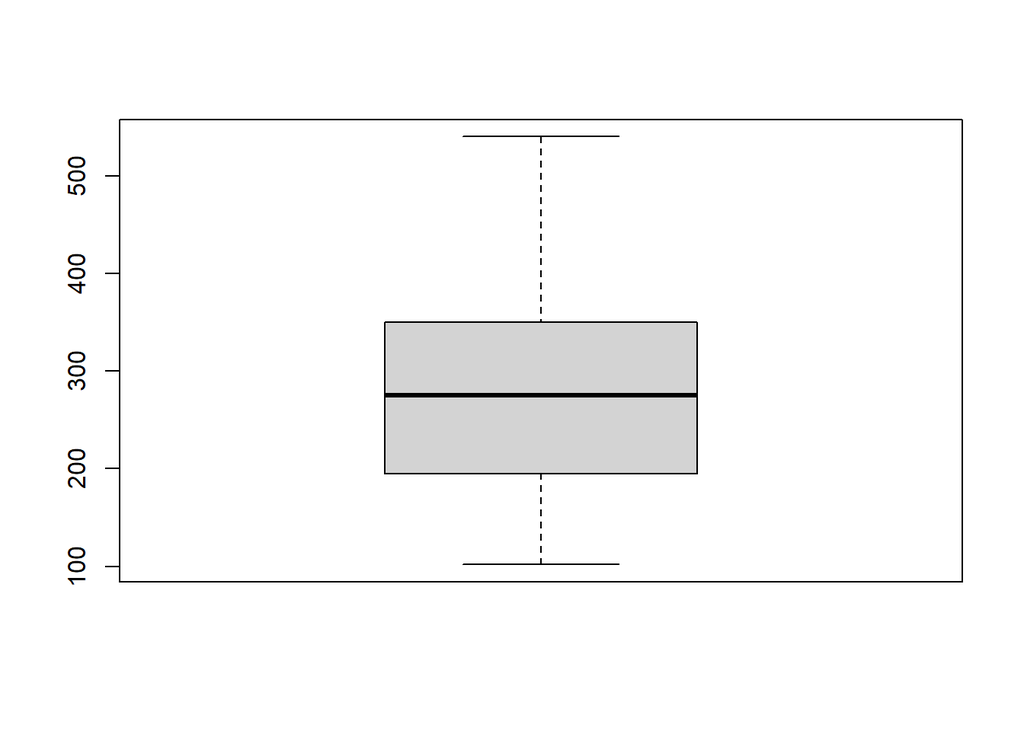

```r
boxplot(train$cement)
```

B. Pada kolom slag terdapat outlier

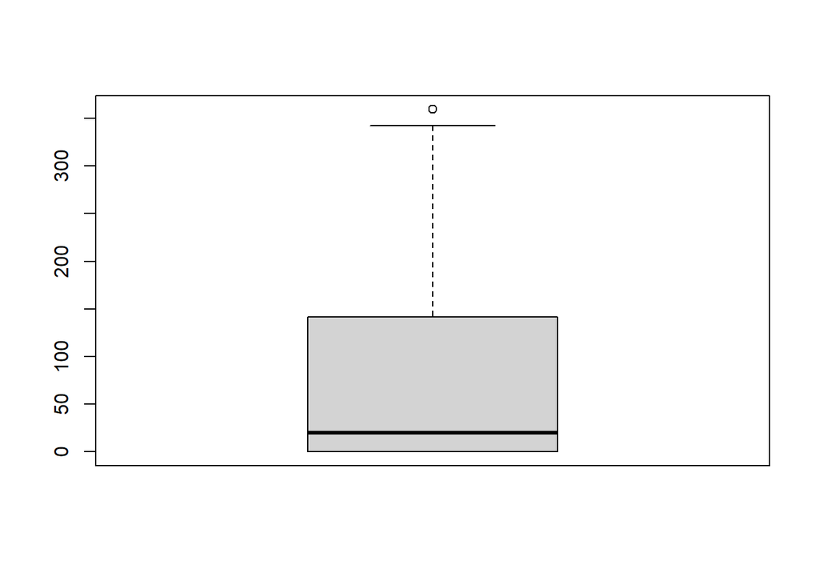

```r
boxplot(train$slag)
```

```r
sort(boxplot(train$slag, plot = F)$out)
```

```
## [1] 359.4 359.4
```

C. Pada kolom flyash tidak terdapat outlier

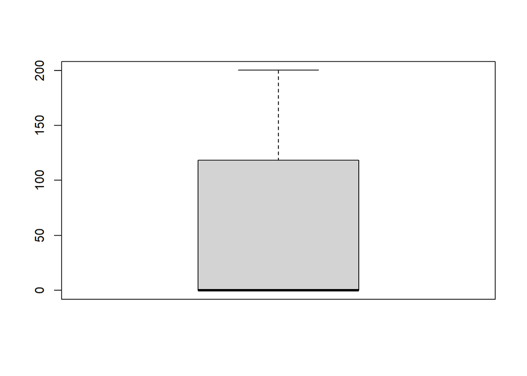

```r
boxplot(train$flyash)
```

D. Pada kolom water terdapat outlier

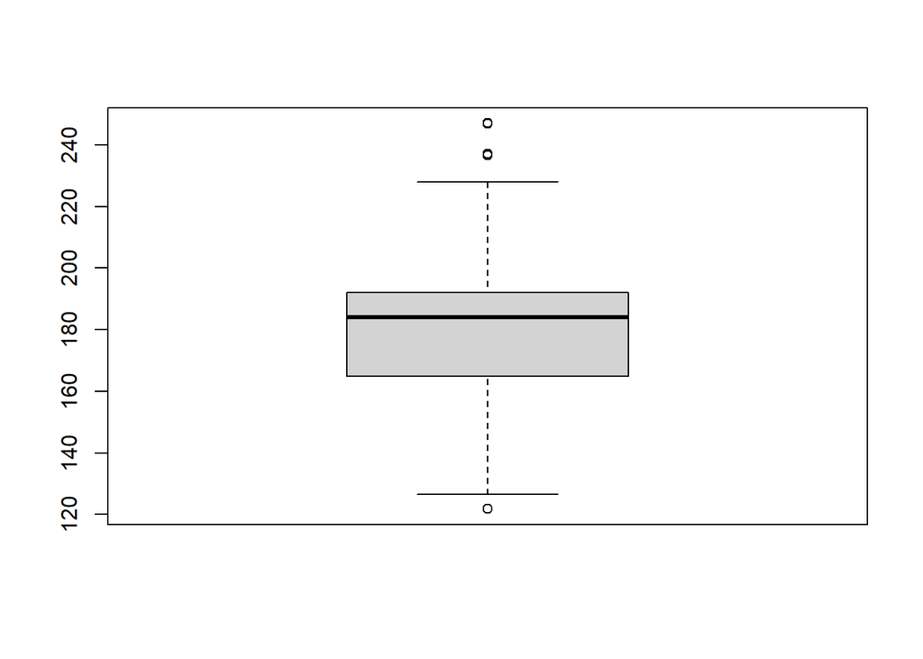

```r
boxplot(train$water)
```

```r
sort(boxplot(train$water, plot = F)$out)
```

```
## [1] 121.8 121.8 121.8 121.8 121.8 236.7 237.0 246.9 247.0
```

E. Pada kolom super_plast terdapat outlier

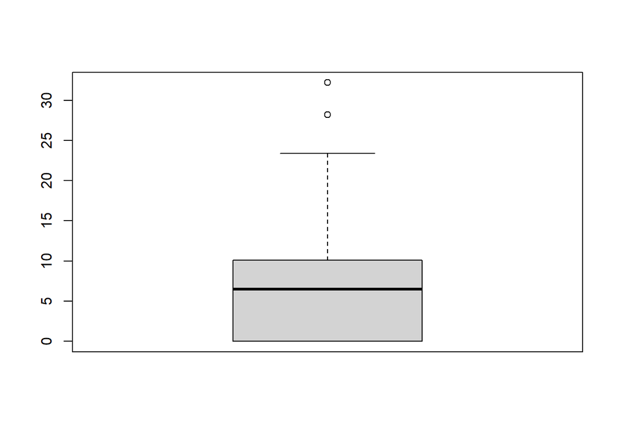

```r
boxplot(train$super_plast)
```

```r
sort(boxplot(train$super_plast, plot = F)$out)
```

```
## [1] 28.2 28.2 28.2 28.2 32.2 32.2 32.2
```

F. Pada kolom coarse_agg tidak terdapat outlier

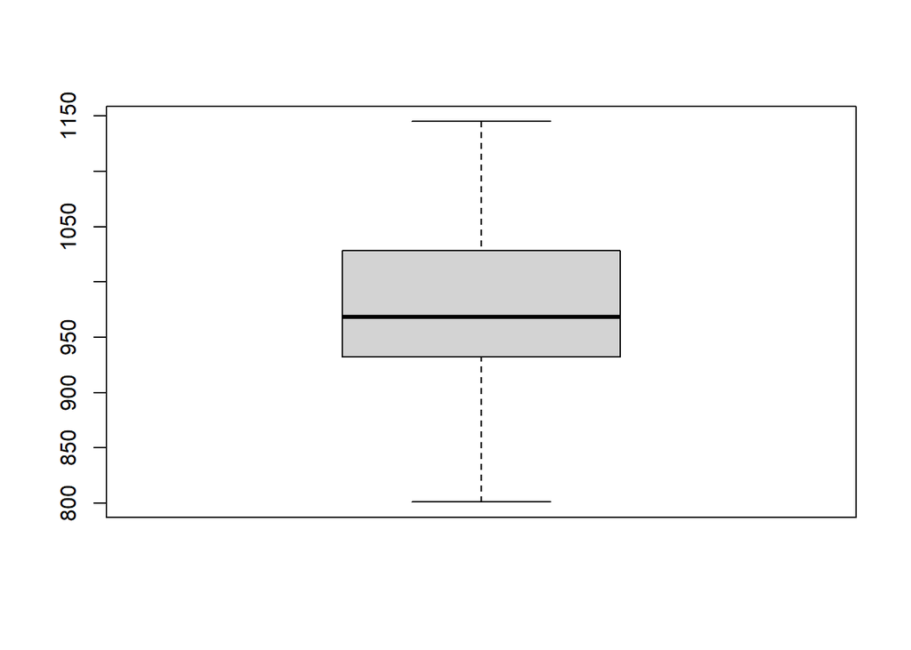

```r
boxplot(train$coarse_agg)
```

G. Pada kolom fine_agg terdapat outlier

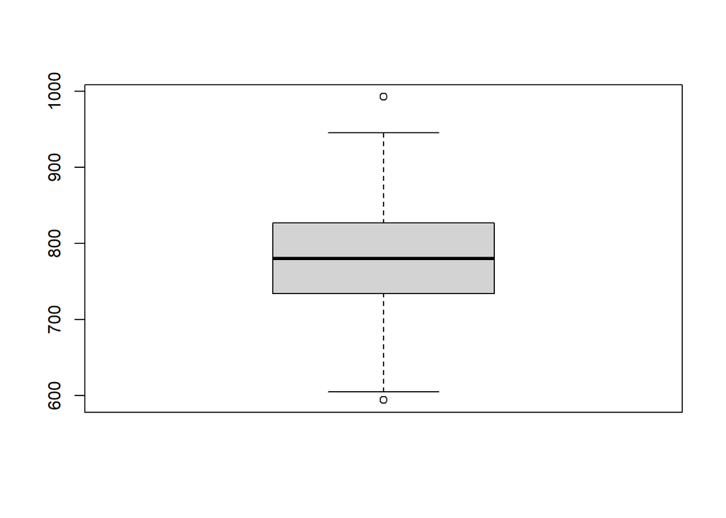

```r
boxplot(train$fine_agg)
```

```r
sort(boxplot(train$fine_agg, plot = F)$out)
```

```
##  [1] 594.0 594.0 594.0 594.0 594.0 594.0 594.0 594.0 594.0 594.0 594.0 594.0
## [13] 594.0 594.0 594.0 594.0 594.0 594.0 594.0 594.0 594.0 594.0 992.6 992.6
## [25] 992.6 992.6 992.6
```

H. Pada kolom age terdapat outlier

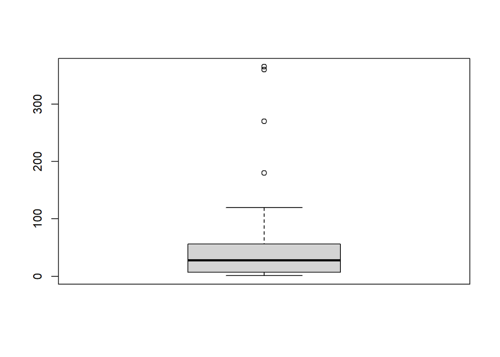

```r
boxplot(train$age)
```

```r
sort(boxplot(train$age, plot = F)$out)
```

```
##  [1] 180 180 180 180 180 180 180 180 180 180 180 180 180 180 180 180 180 180 180
## [20] 180 180 270 270 270 270 270 270 270 270 270 270 360 360 360 360 360 360 365
## [39] 365 365 365 365 365 365 365 365
```

I. Pada kolom strength terdapat outlier

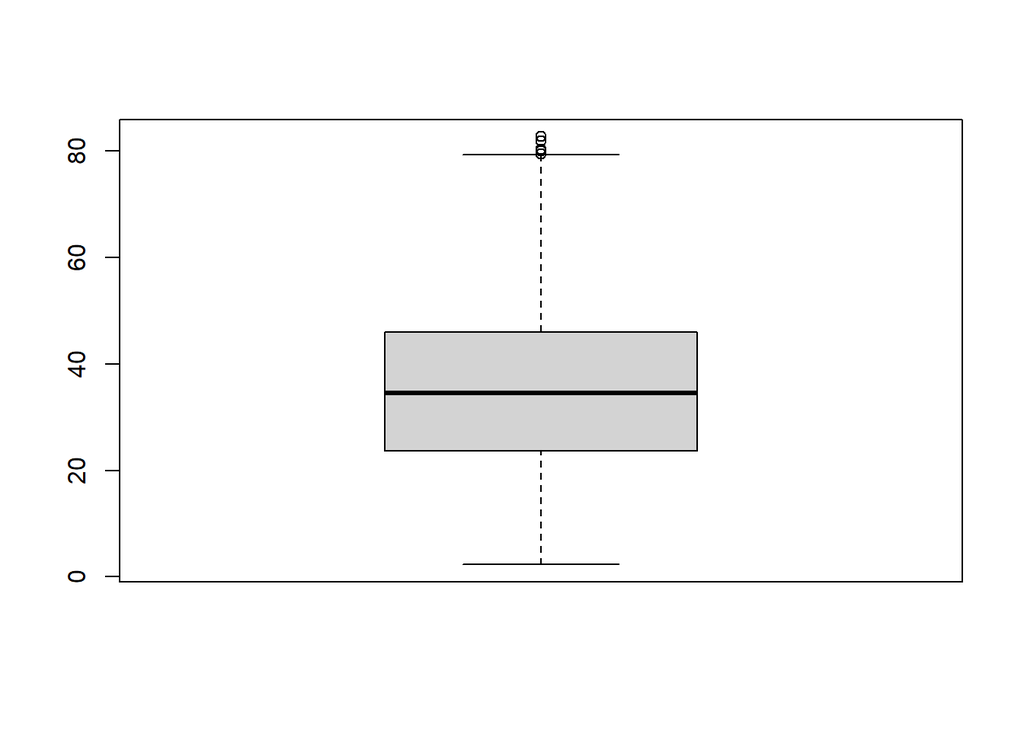

```r
boxplot(train$strength)
```

```r
sort(boxplot(train$strength, plot = F)$out)
```

```
## [1] 79.40 79.99 80.20 81.75 82.60
```

Outlier di kolom strength saya putuskan untuk dihilangkan dengan mensubset data dimana kolom strength < 79.40

```r
train <- train %>%
          subset(strength < 79.40)
```

4. Melihat korelasi

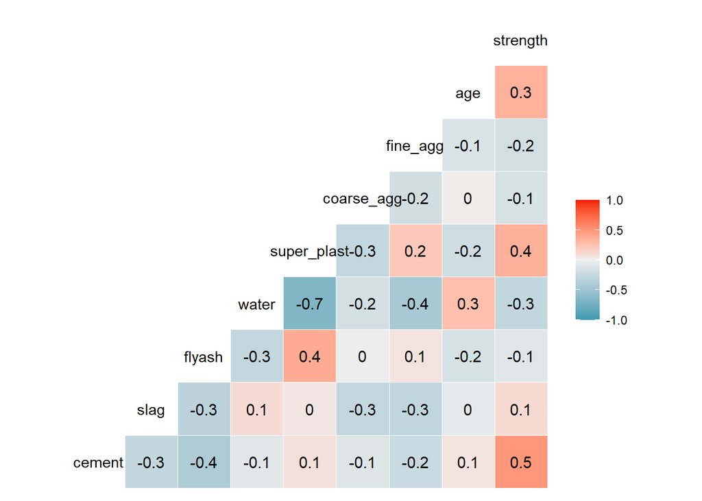

```r
GGally::ggcorr(train, label = T)
```

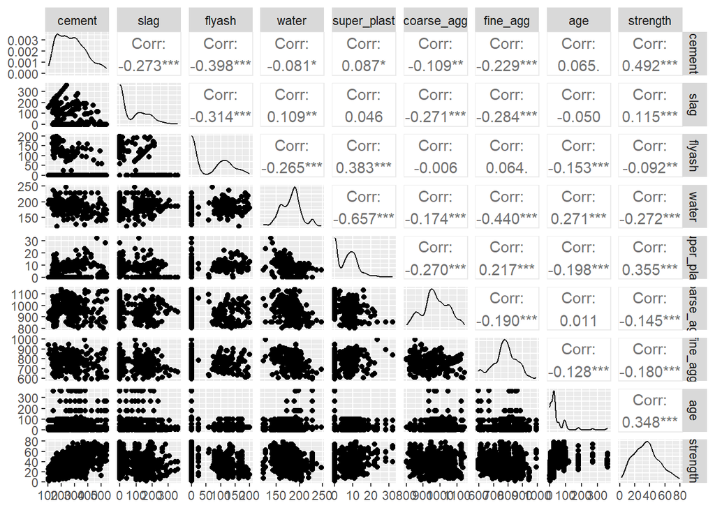

```r
GGally::ggpairs(train)
```

### Model Fitting & Evaluation

Proporsi data train vs data test adalah 80% untuk data train dan 20% untuk data test. Sebelum memprediksi data uji, akan dilakukan validasi silang pada data train untuk membagi 80% data train ke data training dan 20% data train ke data validasi.

1. Cross validation

```r
RNGkind(sample.kind = "Rounding")
set.seed(34)
idx <- sample(nrow(train), nrow(train) * 0.8)
data_train <- train[idx, ]
data_validasi <- train[-idx, ]
```

2. Percobaan Kemungkinan Model

A. Model 1: Simple Regression Model

```r
mod1 <- lm(formula = strength ~., data_train)
mod1 <- stats::step(object = mod1, direction = "backward")
```

```
## Start:  AIC=3097.41
## strength ~ cement + slag + flyash + water + super_plast + coarse_agg +
##     fine_agg + age
##
##               Df Sum of Sq    RSS    AIC
## <none>                      71709 3097.4
## - water        1     358.7  72068 3098.7
## - super_plast  1     487.6  72197 3099.9
## - coarse_agg   1     588.8  72298 3100.8
## - fine_agg     1     627.3  72337 3101.1
## - flyash       1    4256.1  75965 3133.2
## - slag         1    8199.0  79908 3166.4
## - cement       1   14762.4  86472 3218.2
## - age          1   30652.2 102362 3328.9
```

```r
#predict di data train
pred_mod1_train <- predict(mod1, newdata = data.frame(data_train))
#predict di data validasi
pred_mod1_validasi <- predict(mod1, newdata = data.frame(data_validasi))
```

```r
#performance prediksi data train
rbind(
  "Data Train" = select(data_train, strength) %>%
  mutate(
    pred_lm = predict(mod1, data_train)
  ) %>%
  summarise(
    mae = mae_vec(truth = strength, estimate = pred_lm),
    rsq = rsq_vec(truth = strength, estimate = pred_lm),
  ),

  #performance prediksi data validasi
  "Data Validation" = select(data_validasi, strength) %>%
  mutate(
    pred_lm = predict(mod1, data_validasi)
  ) %>%
  summarise(
    mae = mae_vec(truth = strength, estimate = pred_lm),
    rsq = rsq_vec(truth = strength, estimate = pred_lm),
  )
)
```

```
##                      mae       rsq
## Data Train      8.358577 0.5911806
## Data Validation 7.662895 0.6818137
```

Didapat MAE > 4 dan R Square < 90 %, maka dari itu dicoba untuk scaling

```r
# Preprocess recipe train dataset
rec <- recipe(strength ~ ., data = data_train) %>%
  step_sqrt(all_numeric()) %>%
  step_center(all_numeric()) %>%
  step_scale(all_numeric()) %>%
  prep()

# prepare recipes-revert functions
rec_rev <- function(x, rec){

  means <- rec$steps[[2]]$means[["strength"]]
  sds <- rec$steps[[3]]$sds[["strength"]]

  x <- (x * sds + means) ^ 2

  x
}

# apply recipe to train data
dat_train_scaled <- juice(rec)

# apply recipe to test data
dat_test_scaled <- bake(rec, data_validasi)

#modeling with regression
model_lm_scaled <- stats::step(lm(strength ~., data = dat_train_scaled), direction = "backward", trace = 0)

#regression mode performance comparation with scaling and not scaling data
rbind(
  # performance with scaling
 "Scaled" = select(data_validasi, strength) %>%
  mutate(
    pred_lm = predict(model_lm_scaled, dat_test_scaled),
    pred_lm = rec_rev(pred_lm, rec)
  ) %>%
  summarise(
    mae = mae_vec(truth = strength, estimate = pred_lm),
    rsq = rsq_vec(truth = strength, estimate = pred_lm),
  ),

  # performance without scaling
 "Not Scaled" = select(data_validasi, strength) %>%
  mutate(
    pred_lm = predict(mod1, data_validasi)
  ) %>%
  summarise(
    mae = mae_vec(truth = strength, estimate = pred_lm),
    rsq = rsq_vec(truth = strength, estimate = pred_lm),
  )
)
```

```
##                 mae       rsq
## Scaled     5.803299 0.8040983
## Not Scaled 7.662895 0.6818137
```

Dari hasil didapat bahwa data yang di scaled memiliki MAE dan R square yang lebih baik dari sebelumnya. Model 1: Simple Regression belum baik, lalu dicoba model lain.

B. Model 2: Linear Regression & Random Forest dengan penskalaan data/ Data Scaling

```r
set.seed(34)

#modeling with random forest from package randomForest
model_rf <- randomForest(formula =  strength ~ ., data = dat_train_scaled)
```

```r
rbind(
  # performance with linear regression model
 "Regression" = select(data_validasi, strength) %>%
  mutate(
    pred_lm = predict(model_lm_scaled, dat_test_scaled),
    pred_lm = rec_rev(pred_lm, rec)
  ) %>%
  summarise(
    mae = mae_vec(truth = strength, estimate = pred_lm),
    rsq = rsq_vec(truth = strength, estimate = pred_lm),
  ),

  # performance with random forest with package randomForest
 "Random Forest" = select(data_validasi, strength) %>%
  mutate(
    pred_rf = predict(model_rf, dat_test_scaled),
    pred_rf = rec_rev(pred_rf, rec)
  ) %>%
  summarise(
    mae = mae_vec(truth = strength, estimate = pred_rf),
    rsq = rsq_vec(truth = strength, estimate = pred_rf),
  )
)
```

```
##                    mae       rsq
## Regression    5.803299 0.8040983
## Random Forest 3.496140 0.9445154
```

Dapat dilihat bahwa Random Forest memiliki MAE < 4 dan R Square > 90%. Model Terbaik adalah model: RANDOM FOREST

```r
#MODEL TERBAIK: RANDOM FOREST
select(data_validasi, strength) %>%
  mutate(
    pred_rf = predict(model_rf, dat_test_scaled),
    pred_rf = rec_rev(pred_rf, rec)
  ) %>%
  summarise(
    mae = mae_vec(truth = strength, estimate = pred_rf),
    rsq = rsq_vec(truth = strength, estimate = pred_rf),
  )
```

```
##       mae       rsq
## 1 3.49614 0.9445154
```

Diperoleh model Random Forest dengan MAE=3.49614 dan R-Square=0.9445154

### Export Prediction

```r
# apply recipe to test data
dat_test1_scaled <- bake(rec, test)

#predict
pred_test <- select(test, strength) %>%
  mutate(
    pred_rf = predict(model_rf, dat_test1_scaled),
    pred_rf = rec_rev(pred_rf, rec)
  )

#get the value of prediction
pred_rf <- pred_test$pred_rf

#write submission
result <- submit %>% mutate(strength = pred_rf)
write.csv(result, file = "submission-alex.csv")
```

```r
head(result)
```

```
##     id strength
## 1 S826 48.39638
## 2 S827 43.15865
## 3 S828 42.11441
## 4 S829 45.04513
## 5 S830 48.33209
## 6 S831 40.03029
```

### Interpretation With LIME

```r
varImp(model_rf)
```

```
##               Overall
## cement      128.64696
## slag         37.26387
## flyash       31.11481
## water        76.16975
## super_plast  52.38307
## coarse_agg   41.13145
## fine_agg     47.37892
## age         201.25466
```

```r
explainer_caret <- lime(data_train, model_rf)

class(explainer_caret)
```

```
## [1] "data_frame_explainer" "explainer"            "list"
```

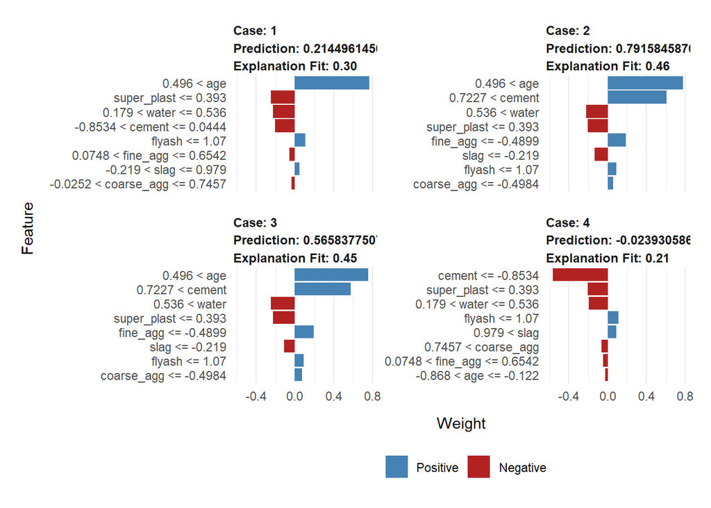

```r
model_type.randomForest <- function(x) {
  return("regression")
}

predict_model.randomForest <- function(x, newdata, type="response") {

  res <- predict(x, newdata, type = "response") %>% as.data.frame()

  return(res)
}

set.seed(34)
explainer <- lime(dat_train_scaled %>% select(-strength), model_rf)
explanation <- explain(dat_test_scaled %>% select(-strength) %>% head(4),
                       explainer,
                       n_features = 8,
                       feature_select = "none"
                       )

plot_features(explanation)
```

A. Kasus 1:

```r
(0.496*rec$steps[[3]]$sds[["age"]] + rec$steps[[2]]$means[["age"]])^2
```

```
## [1] 55.98527
```

```r
(0.393*rec$steps[[3]]$sds[["super_plast"]] + rec$steps[[2]]$means[["super_plast"]])^2
```

```
## [1] 6.696426
```

```r
(-0.0252*rec$steps[[3]]$sds[["coarse_agg"]] + rec$steps[[2]]$means[["coarse_agg"]])^2
```

```
## [1] 967.9963
```

```r
(0.7457*rec$steps[[3]]$sds[["coarse_agg"]] + rec$steps[[2]]$means[["coarse_agg"]])^2
```

```
## [1] 1028.1
```

Interpretasi Kasus 1:

age > 55,98 hari memiliki bobot paling positif (korelasi positif) dalam kekuatan prediksi, sedangkan super_plast <= 6,69 memiliki bobot paling negatif (korelasi negatif) dalam kekuatan prediksi. coarse_agg berkisar antara 967,99 dan 1028,1 yang merupakan faktor yang paling tidak penting untuk kekuatan prediksi dalam kasus 1.

B. Kasus 2:

```r
(0.496*rec$steps[[3]]$sds[["age"]] + rec$steps[[2]]$means[["age"]])^2
```

```
## [1] 55.98527
```

```r
(0.536*rec$steps[[3]]$sds[["water"]] + rec$steps[[2]]$means[["water"]])^2
```

```
## [1] 192.0096
```

```r
(-0.4984*rec$steps[[3]]$sds[["coarse_agg"]] + rec$steps[[2]]$means[["coarse_agg"]])^2
```

```
## [1] 931.9995
```

Interpretasi Kasus 2:

age > 55,98 hari memiliki bobot paling positif (korelasi positif) dalam kekuatan prediksi, sedangkan water > 192.0096 memiliki bobot paling negatif (korelasi negatif) dalam kekuatan prediksi. coarse_agg <= 931,99 adalah faktor yang paling tidak penting untuk kekuatan dalam kasus 2.

```r
(-0.8534*rec$steps[[3]]$sds[["cement"]] + rec$steps[[2]]$means[["cement"]])^2
```

```
## [1] 190.6969
```

```r
(1.07*rec$steps[[3]]$sds[["flyash"]] + rec$steps[[2]]$means[["flyash"]])^2
```

```
## [1] 117.9146
```

```r
(-0.868*rec$steps[[3]]$sds[["age"]] + rec$steps[[2]]$means[["age"]])^2
```

```
## [1] 7.004619
```

```r
(-0.122*rec$steps[[3]]$sds[["age"]] + rec$steps[[2]]$means[["age"]])^2
```

```
## [1] 27.99862
```

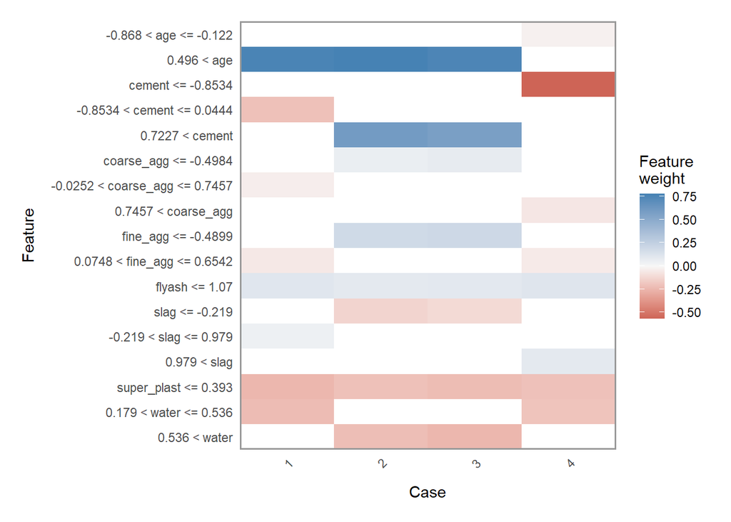

```r
plot_explanations(explanation)
```

### Conclusion

1. Apakah tujuan tercapai?

Dalam kasus ini, tujuan pembentukan model adalah untuk mempredikasi kekuatan berdasarkan sifat sampuran dari mxiture properties seperti water age dll nya. Kinerja model terbaik yaitu Random Forest menghasilkan nilai MAE < 4 dan R-Squared > 90%. Berdasarkan tersebut, tujuan sudah tercapai dengan prediksi menggunakan model Random Forest.

2. Apakah masalah ini dapat diselesaikan dengan machine learning?

Tentu, masalah ini bisa diselesaikan dengan machine learning dalam bentuk model Random Forest. Sebelumnya sudah dicoba menggunakan model regresi dan di scaling, namun hasilnya belum sebaik Random Forest.

3. Model apa yang dipakai dan bagaimana kinerjanya?

Digunakan 2 percobaan model yaitu Model Regresi dan Model Random Forest. Berdasarkan hasil MAE dan R-Squared, model Random Forest adalah model yang terbaik dan saya pakai untuk model prediksi. Kinerjanya tentu baik karena Random Forest menghasilkan MAE=3.49614 dan R-Square=0.9445154 dimana angka tersebut sudah sangat baik.

4. Apa implementasi bisnis potensial dari capstone anda?

Melalui interpretasi LIME, saya dapat mengetahui bahwa ketika age > 55.98 adalah bobot paling positif dalam memprediksi kekuatan yang artinya age > 55.98 lebih bagus untuk sifat campuran.

Kemudian, dengan menggunakan prediksi strength yang sudah saya coba dengan model Random Forest, maka bisa untuk mengoptimalkan harga jual bangunan pada sektor properti dan konstruksi seperti:

1. Desain Struktur: Prediksi kekuatan beton membantu insinyur sipil dan desainer struktur dalam menghitung dimensi dan kapasitas beban yang dapat ditangani oleh struktur beton yang direncanakan.
2. Evaluasi Kualitas Beton: Dengan membandingkan hasil prediksi dengan kekuatan tekan beton aktual yang diukur pada uji laboratorium, dapat dievaluasi kualitas beton yang digunakan dalam proyek konstruksi.
3. Optimasi Campuran Beton: Hasil prediksi dapat digunakan untuk mengoptimalkan campuran beton dengan proporsi bahan tertentu sehingga mencapai kekuatan yang diinginkan.
4. Perencanaan Anggaran: Dalam proyek konstruksi, prediksi kekuatan beton membantu dalam perencanaan anggaran dan sumber daya yang diperlukan.
5. Evaluasi Ketahanan Struktur: Dalam pemeliharaan struktur beton yang ada, prediksi kekuatan beton membantu dalam menilai ketahanan struktur terhadap beban dan kondisi lingkungan.